# DNA_RNA_Project

## 7. Normalize the data using the function preprocessSWAN and compare raw data and normalized data between MUT and WT.

```r
#Standard deviation of Raw Data

dfI <- Illumina450Manifest_clean[Illumina450Manifest_clean$Infinium_Design_Type ==
                                   "I", ]
dfI <- droplevels(dfI)
dfII <- Illumina450Manifest_clean[Illumina450Manifest_clean$Infinium_Design_Type ==
                                    "II", ]
dfII <- droplevels(dfII)

beta_I <- beta[rownames(beta) %in% dfI$IlmnID, ]
dim(beta_I)
```

```
## [1] 135476      8
```

```r
beta_II <- beta[rownames(beta) %in% dfII$IlmnID, ]
dim(beta_II)
```

```
## [1] 350036      8
```

```r
# For each probe in the mean_of_beta_I and mean_of_beta_II matrices, we calculate the mean of beta values across the 8 samples...
mean_of_beta_I <- apply(beta_I, 1, mean)
mean_of_beta_II <- apply(beta_II, 1, mean)

# ... and then we calculate the density distribution of the 2 vectors of mean values:
d_mean_of_beta_I <- density(mean_of_beta_I, na.rm = T)
d_mean_of_beta_II <- density(mean_of_beta_II, na.rm = T)


# For Raw data, we already have the matrix of beta values, the d_mean_of_beta_I and d_mean_of_beta_II objects; we need to calculate the densities of the standard deviations, which can be calculated using the function sd():
sd_of_beta_I <- apply(beta_I, 1, sd, na.rm = T)
sd_of_beta_II <- apply(beta_II, 1, sd, na.rm = T)
d_sd_of_beta_I <- density(sd_of_beta_I, )
sd_of_beta_II <- sd_of_beta_II[!is.na(sd_of_beta_II)]
d_sd_of_beta_II <- density(sd_of_beta_II)

RGset
```

```
## class: RGChannelSet
## dim: 622399 8
## metadata(0):
## assays(2): Green Red
## rownames(622399): 10600313 10600322 ... 74810490 74810492
## rowData names(0):
## colnames(8): GSM5319592_200121140049_R01C02
##   GSM5319603_3999356129_R02C02 ... GSM5319615_3999547017_R04C01
##   GSM5319616_3999547017_R06C01
## colData names(7): SampleID Sex ... Basename filenames
## Annotation
##   array: IlluminaHumanMethylation450k
##   annotation: ilmn12.hg19
```

```r
RGset_SWAN <- preprocessSWAN(RGset)

RGset_SWAN
```

```
## class: MethylSet
## dim: 485512 8
## metadata(0):
## assays(2): Meth Unmeth
## rownames(485512): cg00050873 cg00212031 ... ch.22.47579720R
##   ch.22.48274842R
## rowData names(0):
## colnames(8): GSM5319592_200121140049_R01C02
##   GSM5319603_3999356129_R02C02 ... GSM5319615_3999547017_R04C01
##   GSM5319616_3999547017_R06C01
## colData names(7): SampleID Sex ... Basename filenames
## Annotation
##   array: IlluminaHumanMethylation450k
##   annotation: ilmn12.hg19
## Preprocessing
##   Method: SWAN (based on a MethylSet preprocesses as 'Raw (no normalization or bg correction)'
##   minfi version: 1.54.1
##   Manifest version: 0.4.0
```

```r
head(RGset_SWAN)
```

```
## class: MethylSet
## dim: 6 8
## metadata(0):
## assays(2): Meth Unmeth
## rownames(6): cg00050873 cg00212031 ... cg00455876 cg01707559
## rowData names(0):
## colnames(8): GSM5319592_200121140049_R01C02
##   GSM5319603_3999356129_R02C02 ... GSM5319615_3999547017_R04C01
##   GSM5319616_3999547017_R06C01
## colData names(7): SampleID Sex ... Basename filenames
## Annotation
##   array: IlluminaHumanMethylation450k
##   annotation: ilmn12.hg19
## Preprocessing
##   Method: SWAN (based on a MethylSet preprocesses as 'Raw (no normalization or bg correction)'
##   minfi version: 1.54.1
##   Manifest version: 0.4.0
```

```r
# You see that getBeta is among the accessor functions of a GenomicRatioSet class object
beta_RGset_SWAN <- getBeta(RGset_SWAN)
head(beta_RGset_SWAN)
```

```
##            GSM5319592_200121140049_R01C02 GSM5319603_3999356129_R02C02
## cg00050873                      0.9193586                    0.8561620
## cg00212031                      0.1381156                    0.1490714
## cg00213748                      0.7565424                    0.7638266
## cg00214611                      0.1109598                    0.1035599
## cg00455876                      0.7088608                    0.5577930
## cg01707559                      0.1297422                    0.1340571
##            GSM5319604_3999547012_R02C01 GSM5319607_3999547012_R03C02
## cg00050873                    0.5757576                   0.90473608
## cg00212031                    0.4036797                   0.06369863
## cg00213748                    0.4111205                   0.72524407
## cg00214611                    0.3889418                   0.07410073
## cg00455876                    0.2268421                   0.73277343
## cg01707559                    0.2651693                   0.05812950
##            GSM5319609_3999547016_R02C01 GSM5319613_3999547017_R02C01
## cg00050873                    0.6134868                    0.4244792
## cg00212031                    0.3395639                    0.3665399
## cg00213748                    0.5037736                    0.3649932
## cg00214611                    0.4094595                    0.5925508
## cg00455876                    0.2490421                    0.2237415
## cg01707559                    0.2941176                    0.3349586
##            GSM5319615_3999547017_R04C01 GSM5319616_3999547017_R06C01
## cg00050873                    0.5500000                    0.5546559
## cg00212031                    0.3675000                    0.4014196
## cg00213748                    0.4454054                    0.4570447
## cg00214611                    0.5448997                    0.4406091
## cg00455876                    0.3116751                    0.2517140
## cg01707559                    0.2912424                    0.3083723
```

```r
save(beta_RGset_SWAN, file = "beta_RGset_SWAN.RData")

# Now, as we have done before for raw data, we divide the beta_RGset_SWAN matrix according to type I and type II probes, calculate the mean and the standartd deviation for each probe across the 8 samples and calculate the density distributions
beta_RGset_SWAN_I <- beta_RGset_SWAN[rownames(beta_RGset_SWAN) %in% dfI$IlmnID, ]
beta_RGset_SWAN_II <- beta_RGset_SWAN[rownames(beta_RGset_SWAN) %in% dfII$IlmnID, ]

mean_of_beta_RGset_SWAN_I <- apply(beta_RGset_SWAN_I, 1, mean)
mean_of_beta_RGset_SWAN_II <- apply(beta_RGset_SWAN_II, 1, mean)

d_mean_of_beta_RGset_SWAN_I <- density(mean_of_beta_RGset_SWAN_I, na.rm =
                                         T)
d_mean_of_beta_RGset_SWAN_II <- density(mean_of_beta_RGset_SWAN_II, na.rm =
                                          T)

sd_of_beta_RGset_SWAN_I <- apply(beta_RGset_SWAN_I, 1, sd)
sd_of_beta_RGset_SWAN_II <- apply(beta_RGset_SWAN_II, 1, sd)

d_sd_of_beta_RGset_SWAN_I <- density(sd_of_beta_RGset_SWAN_I, na.rm = T)
d_sd_of_beta_RGset_SWAN_II <- density(sd_of_beta_RGset_SWAN_II, na.rm =
                                        T)
```

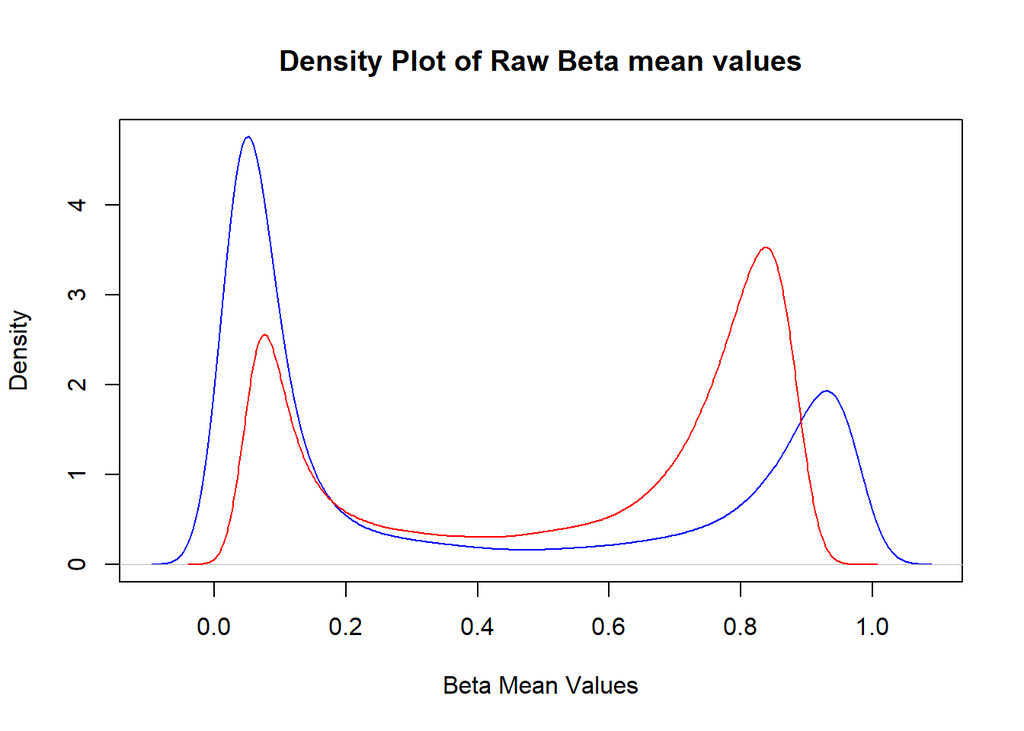

```r
#PLOTS



#Mean of beta Raw and Normalized Data
plot(d_mean_of_beta_I,
     col = "blue",
     main = "Density Plot of Raw Beta mean values",
     xlab = "Beta Mean Values")
lines(d_mean_of_beta_II, col = "red")
```

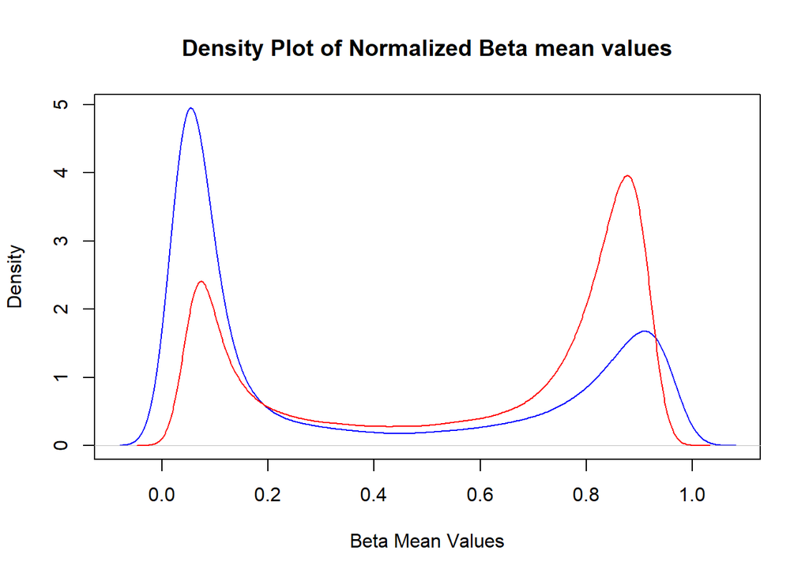

```r
plot(
  d_mean_of_beta_RGset_SWAN_I,
  col = "blue",
  main = "Density Plot of Normalized Beta mean values",
  xlab = "Beta Mean Values"
)
lines(d_mean_of_beta_RGset_SWAN_II, col = "red")
```

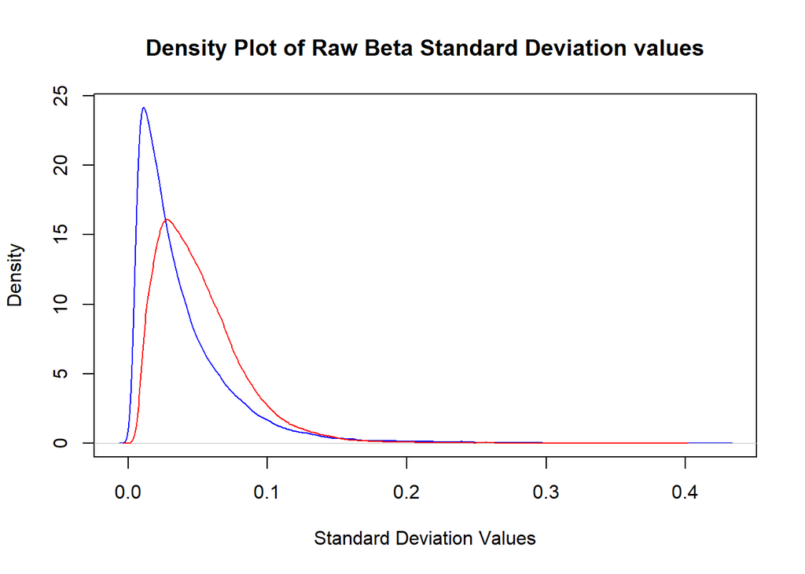

```r
#SD of beta Raw and Normalized Data
plot(d_sd_of_beta_I,
     col = "blue",
     main = "Density Plot of Raw Beta Standard Deviation values",
     xlab = "Standard Deviation Values")
lines(d_sd_of_beta_II, col = "red")
```

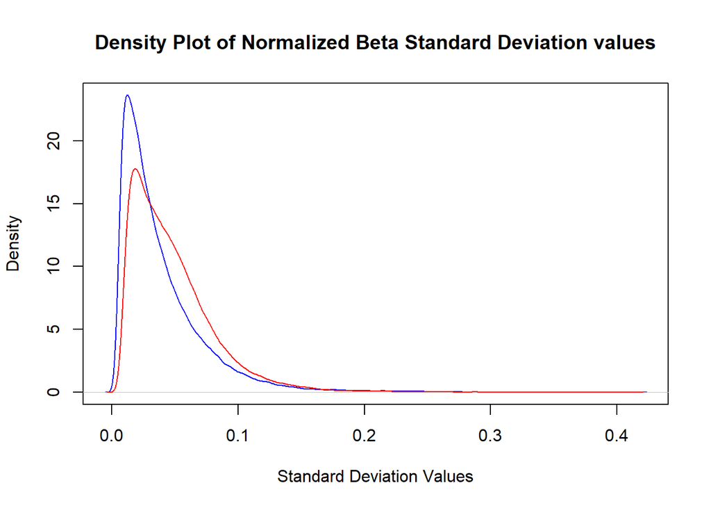

```r
plot(
  d_sd_of_beta_RGset_SWAN_I,
  col = "blue",
  main = "Density Plot of Normalized Beta Standard Deviation values",
  xlab = "Standard Deviation Values"
)
lines(d_sd_of_beta_RGset_SWAN_II, col = "red")
```

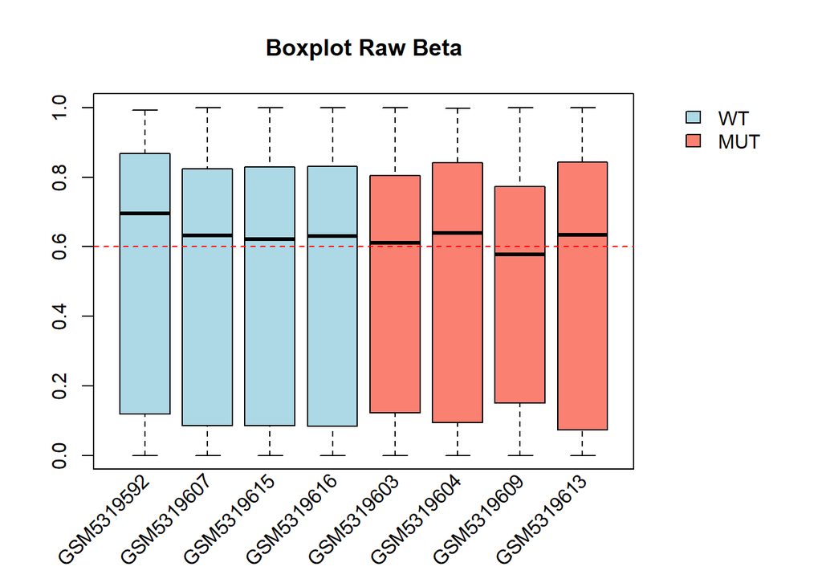

```r
#Boxplots

beta_combined <- cbind(df_ctrl, df_dis)
group_labels <- c(rep("WT", ncol(df_ctrl)), rep("MUT", ncol(df_dis)))
group_colors <- ifelse(group_labels == "WT", "lightblue", "salmon")
par(mar = c(5, 4, 4, 8))
boxplot(beta_combined,
        col = group_colors,
        xaxt = "n",
        main = "Boxplot Raw Beta")
abline(
  h = 0.6,
  col = "red",
  lty = 2,
  lwd = 1
)
short_names <- sapply(strsplit(colnames(beta_combined), "_"), `[`, 1)
text(
  x = 1:length(short_names),
  y = par("usr")[3] - 0.02,
  labels = short_names,
  srt = 45,
  adj = 1,
  xpd = TRUE
)
legend(
  "topright",
  inset = c(-0.25, 0),
  xpd = NA,
  legend = c("WT", "MUT"),
  fill = c("lightblue", "salmon"),
  bty = "n"
)
```

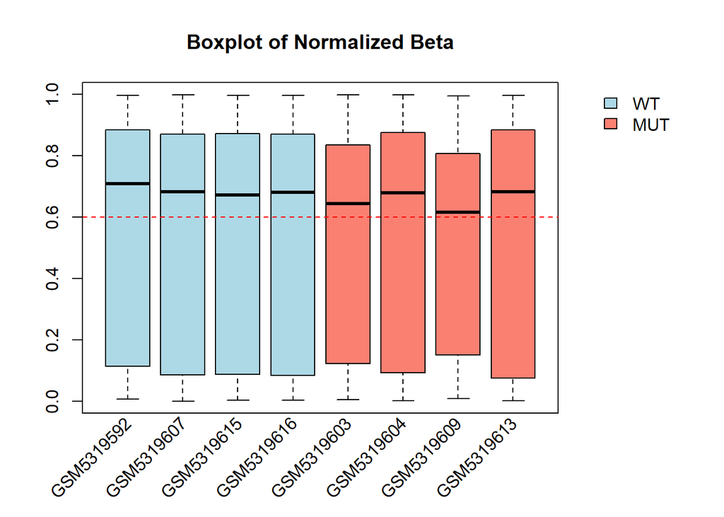

```r
sample_group <- targets$Group
# the same for beta_RGset_SWAN
beta_SWAN_WT <- beta_RGset_SWAN[, sample_group == "CTRL"]
beta_SWAN_MUT <- beta_RGset_SWAN[, sample_group == "DIS"]

beta_SWAN_combined <- cbind(beta_SWAN_WT, beta_SWAN_MUT)
group_labels <- c(rep("WT", ncol(beta_SWAN_WT)), rep("MUT", ncol(beta_SWAN_MUT)))
group_colors <- ifelse(group_labels == "WT", "lightblue", "salmon")
par(mar = c(5, 4, 4, 8))
boxplot(beta_SWAN_combined,
        col = group_colors,
        xaxt = "n",
        main = "Boxplot of Normalized Beta")
abline(
  h = 0.6,
  col = "red",
  lty = 2,
  lwd = 1
)
short_names <- sapply(strsplit(colnames(beta_combined), "_"), `[`, 1)
text(
  x = 1:length(short_names),
  y = par("usr")[3] - 0.02,
  labels = short_names,
  srt = 45,
  adj = 1,
  xpd = TRUE
)
legend(
  "topright",
  inset = c(-0.25, 0),
  xpd = NA,
  legend = c("WT", "MUT"),
  fill = c("lightblue", "salmon"),
  bty = "n"
)
```

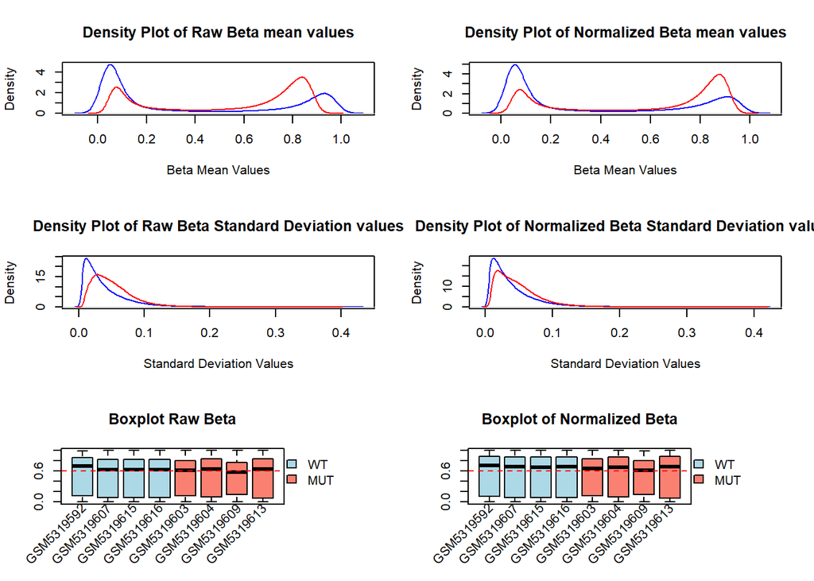

```r
#PLOT with 6 panels, confronting raw and normalized data

par(mfrow = c(3, 2))

#Mean of beta Raw and Normalized Data
plot(d_mean_of_beta_I,
     col = "blue",
     main = "Density Plot of Raw Beta mean values",
     xlab = "Beta Mean Values")
lines(d_mean_of_beta_II, col = "red")
plot(
  d_mean_of_beta_RGset_SWAN_I,
  col = "blue",
  main = "Density Plot of Normalized Beta mean values",
  xlab = "Beta Mean Values"
)
lines(d_mean_of_beta_RGset_SWAN_II, col = "red")

#SD of beta Raw and Normalized Data
plot(d_sd_of_beta_I,
     col = "blue",
     main = "Density Plot of Raw Beta Standard Deviation values",
     xlab = "Standard Deviation Values")
lines(d_sd_of_beta_II, col = "red")
plot(
  d_sd_of_beta_RGset_SWAN_I,
  col = "blue",
  main = "Density Plot of Normalized Beta Standard Deviation values",
  xlab = "Standard Deviation Values"
)
lines(d_sd_of_beta_RGset_SWAN_II, col = "red")

#Boxplots

beta_combined <- cbind(df_ctrl, df_dis)
group_labels <- c(rep("WT", ncol(df_ctrl)), rep("MUT", ncol(df_dis)))
group_colors <- ifelse(group_labels == "WT", "lightblue", "salmon")
par(mar = c(5, 4, 4, 8))
boxplot(beta_combined,
        col = group_colors,
        xaxt = "n",
        main = "Boxplot Raw Beta")
abline(
  h = 0.6,
  col = "red",
  lty = 2,
  lwd = 1
)
short_names <- sapply(strsplit(colnames(beta_combined), "_"), `[`, 1)
text(
  x = 1:length(short_names),
  y = par("usr")[3] - 0.02,
  labels = short_names,
  srt = 45,
  adj = 1,
  xpd = TRUE
)
legend(
  "topright",
  inset = c(-0.25, 0),
  xpd = NA,
  legend = c("WT", "MUT"),
  fill = c("lightblue", "salmon"),
  bty = "n"
)

sample_group <- targets$Group
# the same for beta_RGset_SWAN
beta_SWAN_WT <- beta_RGset_SWAN[, sample_group == "CTRL"]
beta_SWAN_MUT <- beta_RGset_SWAN[, sample_group == "DIS"]

beta_SWAN_combined <- cbind(beta_SWAN_WT, beta_SWAN_MUT)
group_labels <- c(rep("WT", ncol(beta_SWAN_WT)), rep("MUT", ncol(beta_SWAN_MUT)))
group_colors <- ifelse(group_labels == "WT", "lightblue", "salmon")
par(mar = c(5, 4, 4, 8))
boxplot(beta_SWAN_combined,
        col = group_colors,
        xaxt = "n",
        main = "Boxplot of Normalized Beta")
abline(
  h = 0.6,
  col = "red",
  lty = 2,
  lwd = 1
)
short_names <- sapply(strsplit(colnames(beta_combined), "_"), `[`, 1)
text(
  x = 1:length(short_names),
  y = par("usr")[3] - 0.02,
  labels = short_names,
  srt = 45,
  adj = 1,
  xpd = TRUE
)
legend(
  "topright",
  inset = c(-0.25, 0),
  xpd = NA,
  legend = c("WT", "MUT"),
  fill = c("lightblue", "salmon"),
  bty = "n"
)
```

## 8. Perform a PCA on the matrix of normalized beta values generated in step 7, after normalization.

```r
SampleSheet
```

```
##     SampleID    Sex Group   Sentrix_ID Sentrix_Position
## 1 GSM5319592   Male  CTRL 200121140049           R01C02
## 2 GSM5319603   Male   DIS   3999356129           R02C02
## 3 GSM5319604 Female   DIS   3999547012           R02C01
## 4 GSM5319607   Male  CTRL   3999547012           R03C02
## 5 GSM5319609 Female   DIS   3999547016           R02C01
## 6 GSM5319613 Female   DIS   3999547017           R02C01
## 7 GSM5319615 Female  CTRL   3999547017           R04C01
## 8 GSM5319616 Female  CTRL   3999547017           R06C01
```

```r
pca_results <- prcomp(t(beta_RGset_SWAN), scale = T) # Run PCA on transposed methylation data (samples in rows)
print(summary(pca_results))
```

```
## Importance of components:
##                             PC1      PC2      PC3       PC4       PC5       PC6
## Standard deviation     460.7724 285.8759 239.7836 203.35299 199.76188 169.74863
## Proportion of Variance   0.4373   0.1683   0.1184   0.08517   0.08219   0.05935
## Cumulative Proportion    0.4373   0.6056   0.7240   0.80922   0.89141   0.95076
##                              PC7       PC8
## Standard deviation     154.62135 5.887e-12
## Proportion of Variance   0.04924 0.000e+00
## Cumulative Proportion    1.00000 1.000e+00
```

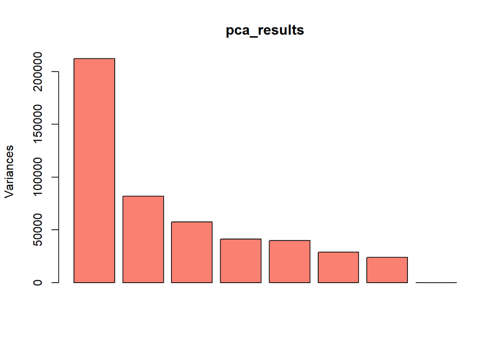

```r
plot(pca_results, col = "salmon") # Scree plot
```

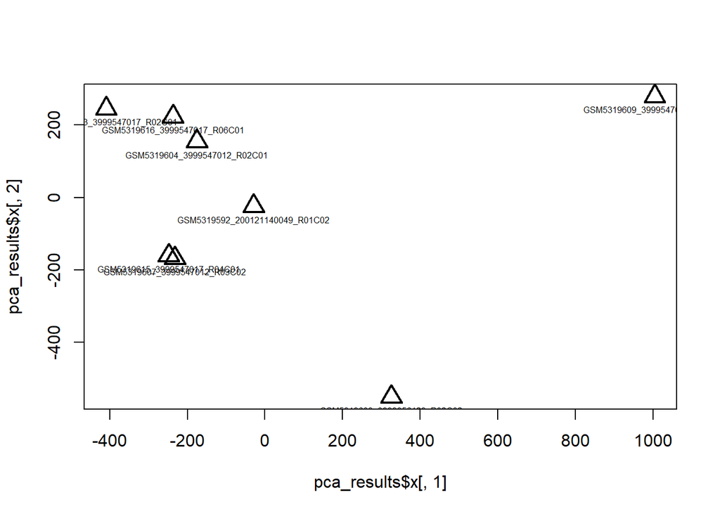

```r
plot(
  pca_results$x[, 1],
  pca_results$x[, 2],
  cex = 2,
  pch = 2,
  lwd = 2
) # PC1 vs PC2 scatterplot
text(
  pca_results$x[, 1],
  pca_results$x[, 2],
  labels = rownames(pca_results$x),
  pos = 1,
  cex = 0.5
)
```

Observation: One sample (GSM5319609_3999547016_R02C01) appears to be an outlier due to a high PC1 value (~1003) in contrast with almost all others with negative values.

```r
# Color samples by group
SampleSheet$Group <- factor(SampleSheet$Group)
levels(SampleSheet$Group)
```

```
## [1] "CTRL" "DIS"
```

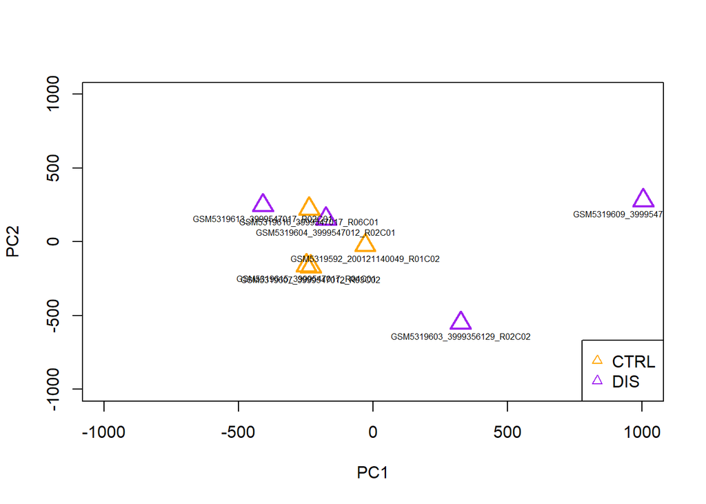

```r
palette(c("orange", "purple"))
plot(
  pca_results$x[, 1],
  pca_results$x[, 2],
  cex = 2,
  pch = 2,
  col = SampleSheet$Group,
  xlab = "PC1",
  ylab = "PC2",
  xlim = c(-1000, 1000),
  ylim = c(-1000, 1000),
  lwd = 2
)
text(
  pca_results$x[, 1],
  pca_results$x[, 2],
  labels = rownames(pca_results$x),
  cex = 0.5,
  pos = 1
)
legend(
  "bottomright",
  legend = levels(SampleSheet$Group),
  col = c(1:nlevels(SampleSheet$Group)),
  pch = 2
)
```

Observation: There’s no clear separation between diseased and control groups. Two diseased samples deviate, but the rest cluster with controls.

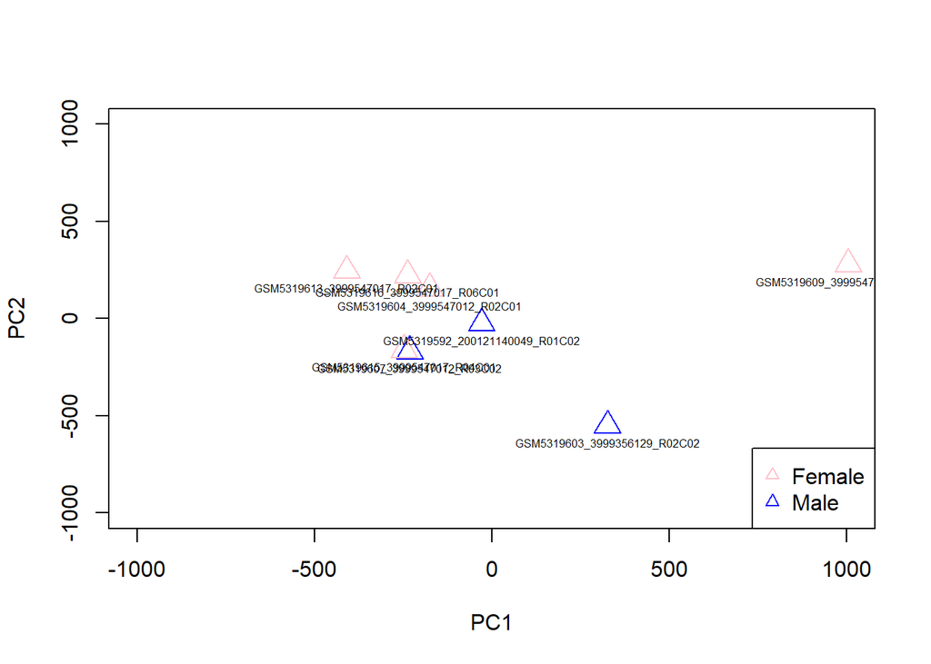

```r
# Color samples by sex
SampleSheet$Sex <- factor(SampleSheet$Sex)
palette(c("pink", "blue"))
plot(
  pca_results$x[, 1],
  pca_results$x[, 2],
  cex = 2,
  pch = 2,
  col = SampleSheet$Sex,
  xlab = "PC1",
  ylab = "PC2",
  xlim = c(-1000, 1000),
  ylim = c(-1000, 1000)
)
text(
  pca_results$x[, 1],
  pca_results$x[, 2],
  labels = rownames(pca_results$x),
  cex = 0.5,
  pos = 1
)
legend(
  "bottomright",
  legend = levels(SampleSheet$Sex),
  col = c(1:nlevels(SampleSheet$Sex)),
  pch = 2
)
```

Observation: Samples do not cluster by sex.

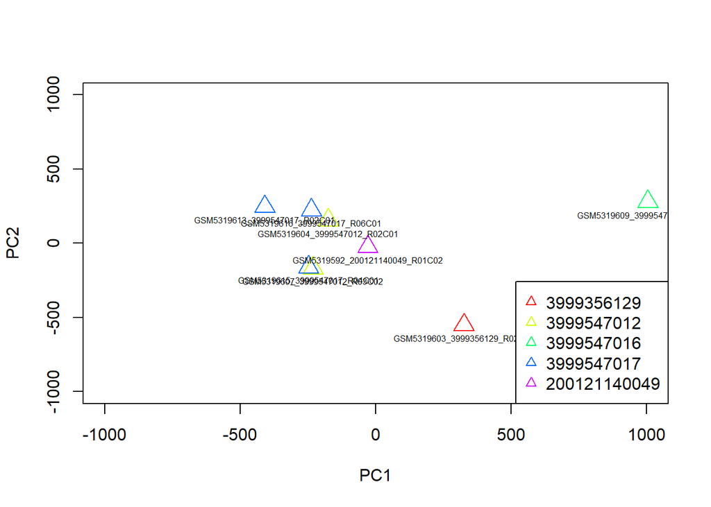

```r
# Color samples by Sentrix ID (array batch)
SampleSheet$Sentrix_ID <- factor(SampleSheet$Sentrix_ID)

palette(rainbow(nlevels(SampleSheet$Sentrix_ID)))
plot(
  pca_results$x[, 1],
  pca_results$x[, 2],
  cex = 2,
  pch = 2,
  col = SampleSheet$Sentrix_ID,
  xlab = "PC1",
  ylab = "PC2",
  xlim = c(-1000, 1000),
  ylim = c(-1000, 1000)
)
text(
  pca_results$x[, 1],
  pca_results$x[, 2],
  labels = rownames(pca_results$x),
  cex = 0.5,
  pos = 1
)
legend(
  "bottomright",
  legend = levels(SampleSheet$Sentrix_ID),
  col = c(1:nlevels(SampleSheet$Sentrix_ID)),
  pch = 2
)
```